# PracticalMachineLearning Course Project

## Goal of the exercise

From http://groupware.les.inf.puc-rio.br/har the description of the dataset includes:

> Six young health participants were asked to perform one set of 10 repetitions of the Unilateral Dumbbell Biceps Curl in five different fashions: exactly according to the specification (Class A), throwing the elbows to the front (Class B), lifting the dumbbell only halfway (Class C), lowering the dumbbell only halfway (Class D) and throwing the hips to the front (Class E).

The task is to model the ‘classe’ variable based on any of the variables included in the set.

## Data loading, initial exploration and cleaning

First we load the two data sets as follows, and look at the problems:

```r
train <- read_csv('pml-training.csv') %>% select(-X1) %>% mutate(classe = factor(classe, levels = LETTERS[1:5]))
test <- read_csv('pml-testing.csv') %>% select(-X1) #%>%  mutate(classe = factor(classe, levels = LETTERS[1:5]))
```

Checking the warnings we can see that 182 data points have NA values for some rows in the training set.

```r
problems(read_csv('pml-training.csv')) %>% group_by(col) %>% summarize(n= n()) %>% arrange(desc(n))
```

```
## # A tibble: 9 x 2
##   col                         n
##   <chr>                   <int>
## 1 kurtosis_roll_arm          78
## 2 skewness_roll_arm          77
## 3 amplitude_yaw_dumbbell      5
## 4 kurtosis_roll_dumbbell      5
## 5 max_yaw_dumbbell            5
## 6 min_yaw_dumbbell            5
## 7 skewness_roll_dumbbell      4
## 8 kurtosis_picth_dumbbell     2
## 9 skewness_pitch_dumbbell     1
```

Many of the columns are not substantially populated. I chose to eliminate those columns. Furthermore, we are interested in only the sensor data and the classe output and therefore we shall eliminate the reminder of columns.

```r
train = train[, apply(train, 2, function (x) sum(is.na(x))) %>% subset(., . < 1000) %>% names]
train = train[, -(1:6)]
```

Verify the yielding training set contains fully populated columns.

```r
sum(apply(train, 2, function (x) sum(is.na(x))) > 0 )
```

```
## [1] 0
```

We end up with 52 data columns + 1 column for the outcome.

## Data exploration

Let’s look at the variability of variables ending in x, y, z. First, select those variables and plot them in alphabetic order. Further, normalize all variables proportionally between 0 and 1 to be comparable.

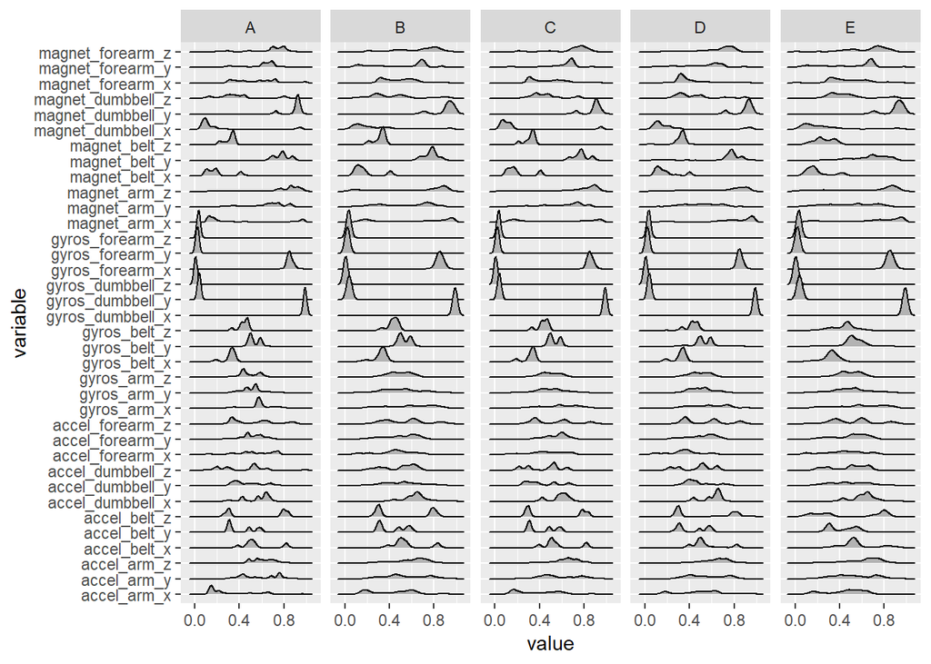

```r
dplot1_unnorm <- train %>% select(ends_with('x'), ends_with ('y'), ends_with('z')) %>% select(., sort(names(.)))
dplot1_cast <- dplot1_unnorm %>% apply(., 2, function(x) (x - min(x)) / (max(x) - min(x))) %>% tbl_df
dplot1_cast$classe <- train$classe
dplot1 <- melt(dplot1_cast, id.vars='classe')
ggplot(dplot1, aes(x=value, y=variable, height=..density..)) + facet_grid(. ~ classe) + geom_density_ridges()
```

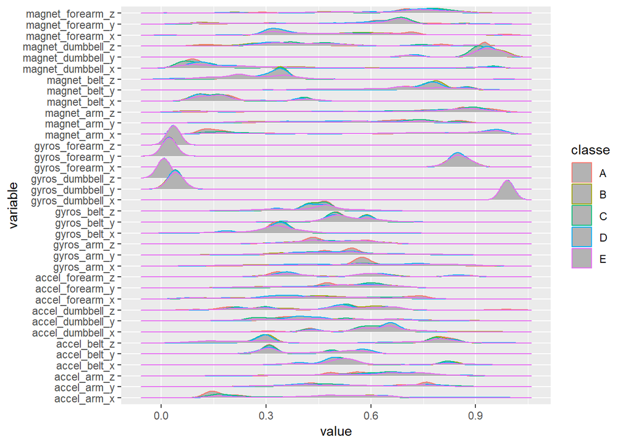

```r
ggplot(dplot1, aes(x=value, y=variable, height=..density.., color = classe)) + geom_density_ridges()
```

Clearly such a bulk approach is not useful. Let’s look at one of the spatial variables sets individually:

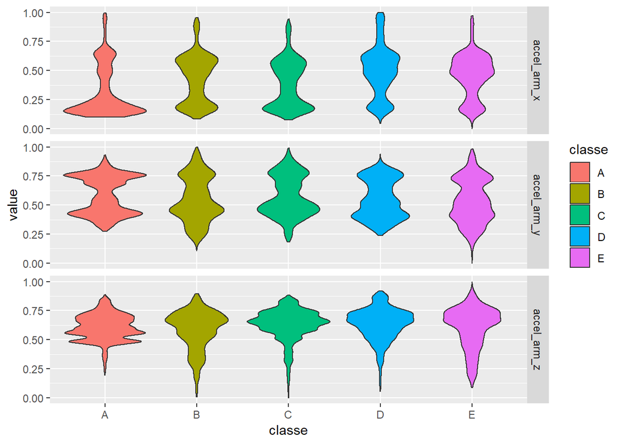

```r
dplot1_cast[, c(1:3, 37)] %>% melt(id.vars = 'classe') %>% ggplot(aes(classe, value)) + facet_grid(variable ~ .) + geom_violin(aes(fill = classe))
```

Variability among the classes is indeed in there, but no clear separation.

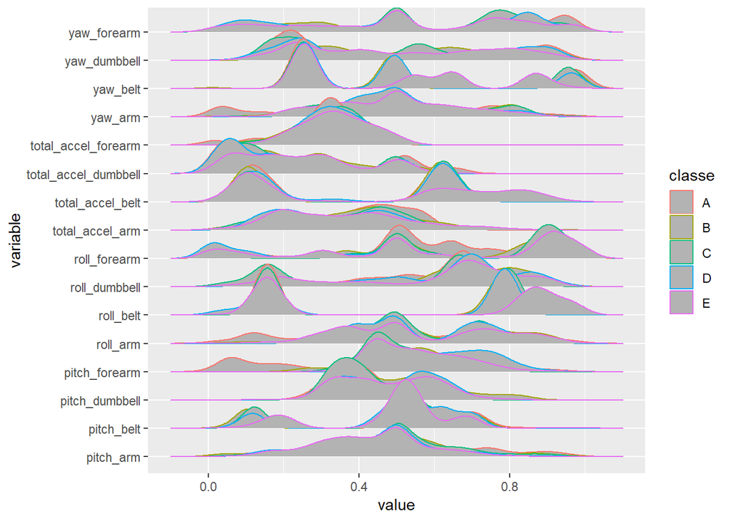

```r
dplot2_unnorm <- train %>% select(-ends_with('x'), -ends_with ('y'), -ends_with('z'), -classe) %>% select(., sort(names(.)))
dplot2_cast <- dplot2_unnorm %>% apply(., 2, function(x) (x - min(x)) / (max(x) - min(x))) %>% tbl_df
dplot2_cast$classe <- train$classe
dplot2 <- melt(dplot2_cast, id.vars='classe')
ggplot(dplot2, aes(x=value, y=variable, height=..density.., color = classe)) + geom_density_ridges()
```

Distinctions do exist, especially in the ‘belt’ variables

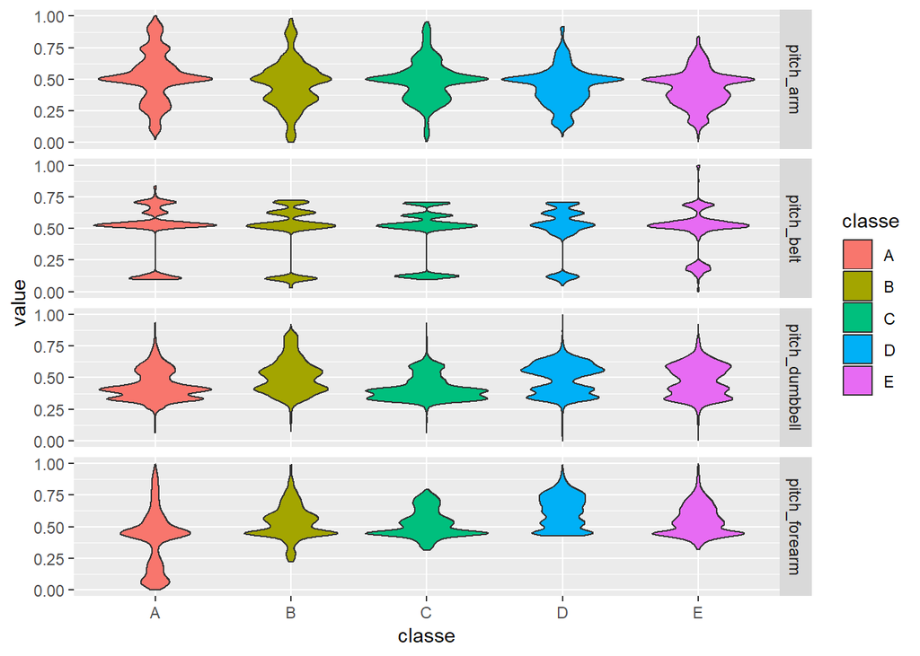

```r
dplot2_cast[, c(1:4, 17)] %>% melt(id.vars = 'classe') %>% ggplot(aes(classe, value)) + facet_grid(variable ~ .) + geom_violin(aes(fill = classe))
```

## Dimension reduction

To attempt a modeling approach I choose to first extract the principal components, due to the high number of variables with non-visibile distinctions.

```r
preProcess(train %>% select(-classe), method = 'pca')
```

```
## Created from 19622 samples and 52 variables
##
## Pre-processing:
##   - centered (52)
##   - ignored (0)
##   - principal component signal extraction (52)
##   - scaled (52)
##
## PCA needed 25 components to capture 95 percent of the variance
```

Let’s attempt a tree model first and see how it performs

```r
mrpart <- train(classe ~ ., data = train, method = 'rpart')
confusionMatrix(train$classe, predict(mrpart, train))
```

```
## Confusion Matrix and Statistics
##
##           Reference
## Prediction    A    B    C    D    E
##          A 5080   81  405    0   14
##          B 1581 1286  930    0    0
##          C 1587  108 1727    0    0
##          D 1449  568 1199    0    0
##          E  524  486  966    0 1631
##
## Overall Statistics
##
##                Accuracy : 0.4956
##                  95% CI : (0.4885, 0.5026)
##     No Information Rate : 0.5209
##     P-Value [Acc > NIR] : 1
##
##                   Kappa : 0.3407
##
##  Mcnemar's Test P-Value : NA
##
## Statistics by Class:
##
##                      Class: A Class: B Class: C Class: D Class: E
## Sensitivity            0.4970  0.50850  0.33040       NA  0.99149
## Specificity            0.9468  0.85310  0.88225   0.8361  0.89008
## Pos Pred Value         0.9104  0.33869  0.50468       NA  0.45218
## Neg Pred Value         0.6339  0.92145  0.78395       NA  0.99913
## Prevalence             0.5209  0.12889  0.26638   0.0000  0.08383
## Detection Rate         0.2589  0.06554  0.08801   0.0000  0.08312
## Detection Prevalence   0.2844  0.19351  0.17440   0.1639  0.18382
## Balanced Accuracy      0.7219  0.68080  0.60633       NA  0.94079
```

Clearly not working. Let’s try a random forest

```r
mrf <- randomForest(classe ~ ., data = train)
confusionMatrix(train$classe, predict(mrf, train))
```

```
## Confusion Matrix and Statistics
##
##           Reference
## Prediction    A    B    C    D    E
##          A 5580    0    0    0    0
##          B    0 3797    0    0    0
##          C    0    0 3422    0    0
##          D    0    0    0 3216    0
##          E    0    0    0    0 3607
##
## Overall Statistics
##
##                Accuracy : 1
##                  95% CI : (0.9998, 1)
##     No Information Rate : 0.2844
##     P-Value [Acc > NIR] : < 2.2e-16
##
##                   Kappa : 1
##
##  Mcnemar's Test P-Value : NA
##
## Statistics by Class:
##
##                      Class: A Class: B Class: C Class: D Class: E
## Sensitivity            1.0000   1.0000   1.0000   1.0000   1.0000
## Specificity            1.0000   1.0000   1.0000   1.0000   1.0000
## Pos Pred Value         1.0000   1.0000   1.0000   1.0000   1.0000
## Neg Pred Value         1.0000   1.0000   1.0000   1.0000   1.0000
## Prevalence             0.2844   0.1935   0.1744   0.1639   0.1838
## Detection Rate         0.2844   0.1935   0.1744   0.1639   0.1838
## Detection Prevalence   0.2844   0.1935   0.1744   0.1639   0.1838
## Balanced Accuracy      1.0000   1.0000   1.0000   1.0000   1.0000
```

WOW! We have a very accurate model, now

```r
predict(mrf, test)
```

```
##  1  2  3  4  5  6  7  8  9 10 11 12 13 14 15 16 17 18 19 20
##  B  A  B  A  A  E  D  B  A  A  B  C  B  A  E  E  A  B  B  B
## Levels: A B C D E
```